# Type de jeux en ligne sur Steam

Hoang-Viêt LE

2025-04-24

# Avant l’analyse…

## Importation des données

Dans cette partie, on doit importer les données dans les différents fichiers et réaliser tout le nécessaire afin d’obtenir un dataframe avec toutes les informations que l’on veut afin de l’exploiter pour notre analyse et nos visualisations.

Ce que l’on a à faire :

- Tous les tableaux partagent une colonne commune : `app_id`, qui sera utilisée pour les jointures. On va alors créé un grand dataframe avec l’ensemble des variables que l’on veut exploiter.
- Certaines colonnes nécessitent un nettoyage, notamment la colonne `initial_price` contenant parfois la valeur “\N”
- Regrouper les tags et les catégories sur une même ligne (même `app_id`) des fichiers `tags.csv` et `categories.csv` : les colonnes `tags` et `categories` seront des chaînes de caractères contenant l’ensemble des tags/catégories séparés chacun par une virgule
- Convertir `initial_price` en une donnée exploitable dans `steamspy.csv` (ex : 999 veut dire 9.99 USD)

## Différences entre “Catégorie” et “Tag”

Sur Steam, il existe deux types de variables qui permettent de classer les jeux présents sur la plateforme :

- Catégories : classifications officielles attribuées par Steam. Elles décrivent les fonctionnalités principales d’un jeu (par exemple : Multijoueur, Succès Steam, Support manette, Mode coopératif, etc.). Ce sont des critères souvent liés à l’expérience utilisateur et aux fonctionnalités techniques du jeu.
- Tags : classifications collaboratives créées par les utilisateurs de Steam. Ils permettent de décrire le contenu, l’ambiance ou le style d’un jeu (par exemple : Puzzle, Narratif, Indépendant, FPS, Monde ouvert, etc.). Les tags sont plus subjectifs et peuvent varier en popularité selon la communauté.

[figure not shown]

Tags et Catégories de Portal 2 sur Steam

# Analyse

## Contexte et problématique

C’est sur la plateforme Steam que l’on a vu naître les premiers jeux en ligne et le développement de celui-ci avec des jeux mythiques comme Counter Strike, Team Forteress, etc… D’autres types de jeux sont aussi devenus populaires au cours du temps comme les MMORPG, les Battle-Royale, etc… Nous voulons voir les tendances actuelles et quels types de jeux attirent principalement les joueurs de Steam.

Notre problématique est alors la suivante :

Quels sont les types de jeu en ligne les plus populaires sur Steam ? (FPS, MMO, etc…)

## Définition de jeu en ligne

Une définition de jeu en ligne sera un jeu vidéo dont l’expérience se repose sur l’intéraction entre plusieurs joueurs en temps réel. On distingue différents types de jeu en ligne :

- MMO (Massive Multiplayer Online)
- Jeux coméptitifs (FPS, MOBA, Battle Royale)
- Jeux collaboratifs (Eurotruck 2)

### Critères “jeu en ligne” :

Dans nos données, nous identifierons un jeu comme “jeu en ligne” s’il possède les catégories ou tags suivants :

- “Multi-player”, “Massively Multiplayer”, “Online Co-op”, ou d’autres tags associés.

### Critère “popularité” :

Le critère “popularité” sera basée sur le nombre de joueurs actifs en Octobre 2024.

## Analyse des résultats

Voici la répartition des joueurs sur la plateforme Steam sur les jeux en lignes :

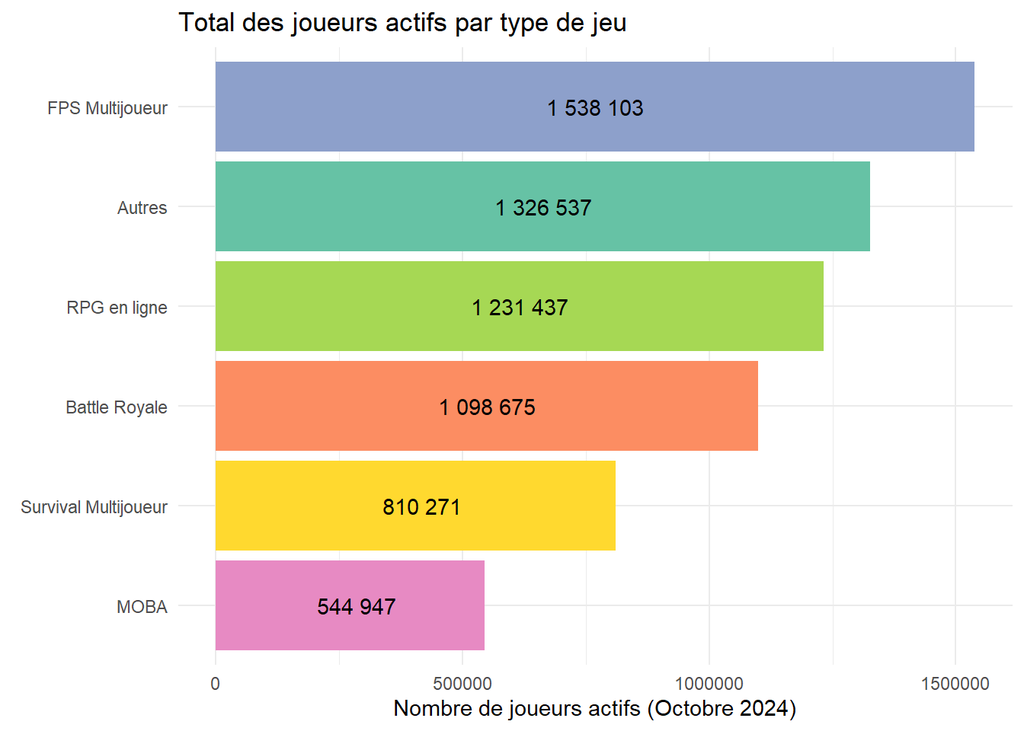

### Observations

Ensuite, dans la catégorie “Autres”, On y compte 1,3 millions joueurs sur des jeux comme Liar’s Bar, War Thunder, Civizilation VI, Forza Horizon et Eurotruck Simulator 2. C’est une catégorie regroupant pleins de genres différents.

Ensuite, les Battle Royale rassemble 1 million de joueurs (environ 16,5% des joueurs). Le genre semble être resté populaire mais elle n’a plus la même popularité qu’entre 2018-2020.

Les RPG en ligne représentent 1.2 million de joueurs mais il faut distinguer les différents genre de RPG en ligne.

En effet, dans les RPG en ligne, ils se trouvent les MMO comme Monster Hunter: World, New World: Aeternum ou Destiny 2 mais également des RPG qui peut se jouer en coopération comme Stardew Valley, Baldur’s Gate 3, etc…

Voici la répartition des joueurs jouant à des MMORPG et des joueurs de RPG classique :

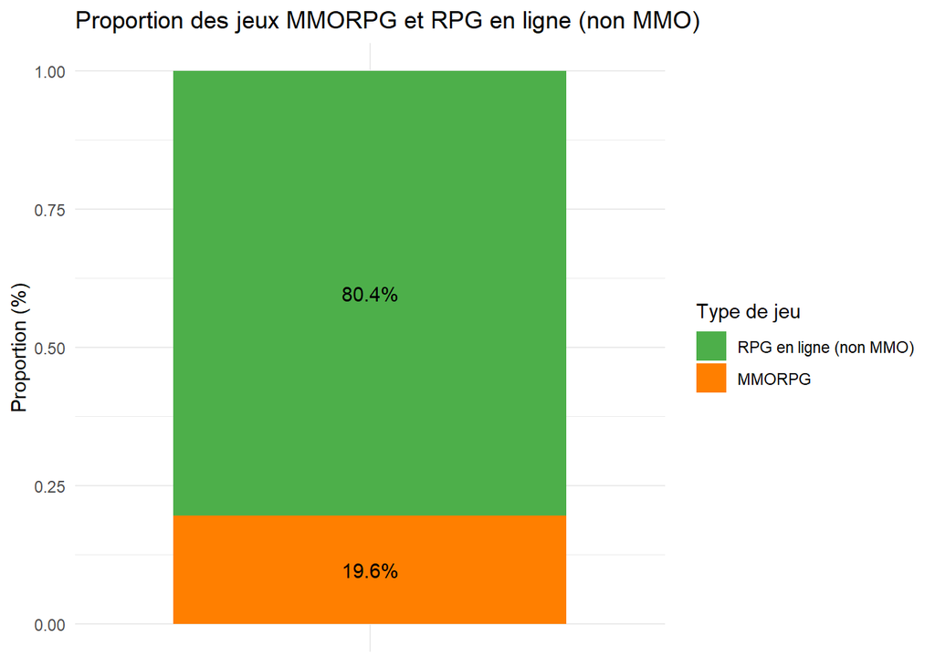

Note : Stardew Valley a le tag RPG et est un jeu qui peut se jouer en multijoueur mais peut-on considérer comme un jeu en ligne ? C’est le cas d’autres jeux principalement singleplayer mais qui peut se jouer en multijoueur.

Les Survival Multijoueur représentent une base de 800 000 joueurs sur des jeux phares comme Rust, Factorio, Satisfactory, etc…

Enfin, les MOBA représentent uniquement moins de 550 000 joueurs dont la majorité des joueurs viennent de Dota 2 (500 000 joueurs).

### Limites de résultats obtenus

- Les tags Steam et les catégories créées ne sont pas assez précises pour trouver les jeux en ligne car on se retrouve souvent à la frontière d’un jeu avec un système multijoueur et un jeu en ligne.
- D’autres visualisations au sein des catégories nous permettraient de voir qu’uniquement quelques jeux portent la base de jeu de certains types de jeux comme CS 2 pour les FPS et Dota 2 pour les MOBA.
- Le fait que la catégorie “Autres” possèdent de nombreux jeux en ligne que l’on a pas pu classer montre que le domaine des jeux en ligne est très variée et non cantonnée aux genres que l’on pense habituellement. Globalement, réaliser une classification sur l’ensemble des jeux Steam semble difficile tant certains jeux sont assez particulier pour les catégoriser.
- Enfin, il faut être conscient que ces données ne concernent que les utilisateurs Steam et non la globalité des joueurs. Par exemple, pour les MMORPG, ceux-ci peuvent être lancés hors Steam. De plus avec l’avènement de l’Epic Game Store, une partie des jeux sont passés sur l’autre plateforme comme Rocket League.